# Clustering Nonhirarki (K-Means)

Sehingga jika dibandingkan dengan metode sebelumnya maka dapat ditarik keputusan nilai k yang optimal untuk membentuk klaster adalah 6.

Kita juga dapat melihat plot data dalam ruang tiga dimensi sesuai jumlah variabel yang kita gunakan sebagai dimensinya.

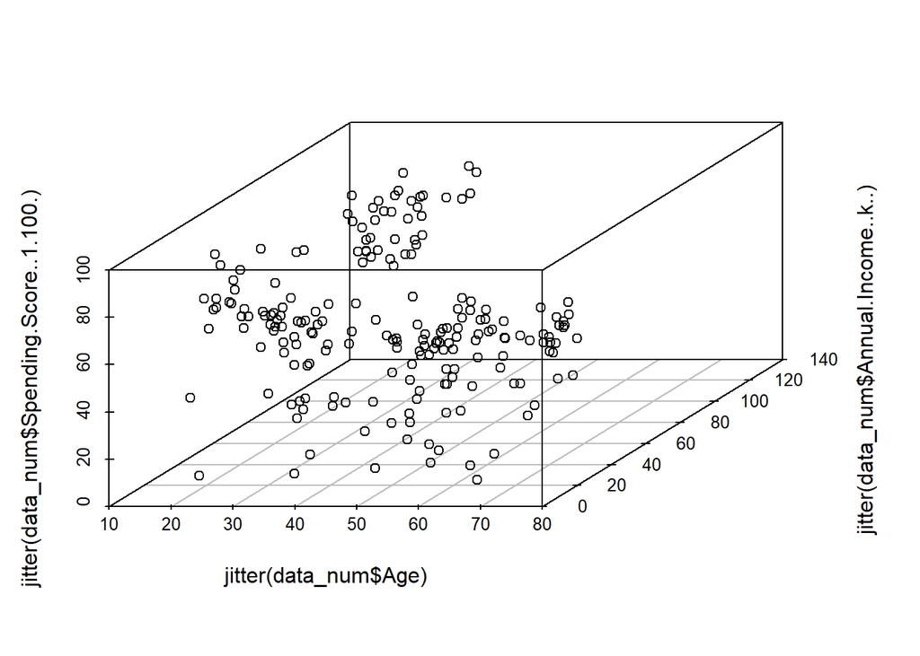

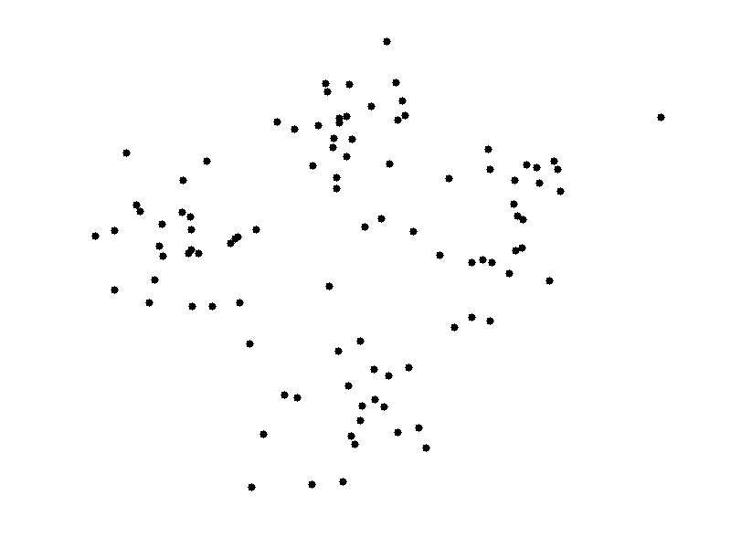

Clustering Kmeans

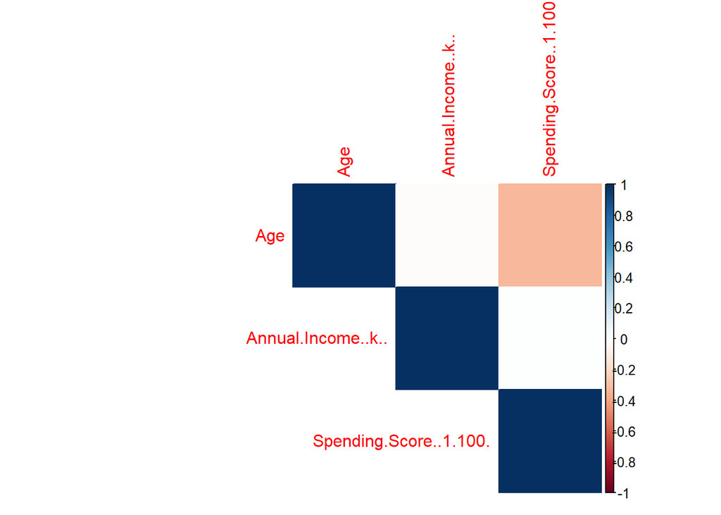

## Analisis KMeans dengan kluster optimal

K optimal yang telah didaptkan sebelumnya dapat kita gunakan untuk melakukan analisis cluster K-Means. Baris kedua dapat digunakan untuk memilih metode penghitungan jarak yang diinginkan, diantaranya “euclidean”, “maximum”, “manhattan”, “canberra”, “binary”, “minkowski”, “pearson”, “spearman” atau “kendall”. Namun baris tersebut tidak kita eksekusi, karena kita akan menggunakan Euclidian Distance yang sudah secara default dipakai tanpa perlu kita atur dalam fungsi kmeans().

```r
set.seed(123)
#data_fix = get_dist(data_num, method = "euclidean", stand = TRUE)
clus_cust = kmeans(data_fix,6)
clus_cust
```

```
## K-means clustering with 6 clusters of sizes 13, 57, 22, 22, 40, 46
##
## Cluster means:
##          Age Annual.Income..k.. Spending.Score..1.100.
## 1 -0.6005052          1.1003939             -1.4256531
## 2  1.1950641         -0.4802119             -0.3216162
## 3 -0.9719569         -1.3262173              1.1293439
## 4  0.6777992          1.0257105             -1.1853182
## 5 -0.4277326          0.9724070              1.2130414
## 6 -0.7985068         -0.4177864             -0.2266218
##
## Clustering vector:
##   [1] 6 3 6 3 6 3 6 3 2 3 2 3 2 3 6 3 6 3 2 3 6 3 2 3 2 3 2 3 6 3 2 3 2 3 2 3 2
##  [38] 3 6 3 2 3 2 6 2 3 2 6 6 6 2 6 6 2 2 2 2 2 6 2 2 6 2 2 2 6 2 2 6 6 2 2 2 2
##  [75] 2 6 2 6 6 2 2 6 2 2 6 2 2 6 6 2 2 6 2 6 6 6 2 6 2 6 6 2 2 6 2 6 2 2 2 2 2
## [112] 6 6 6 6 6 2 2 2 2 6 6 5 5 6 5 4 5 4 5 4 5 6 5 1 5 4 5 1 5 4 5 6 5 1 5 4 5
## [149] 1 5 4 5 4 5 4 5 1 5 1 5 4 5 1 5 4 5 4 5 1 5 4 5 1 5 4 5 4 5 4 5 1 5 4 5 4
## [186] 5 4 5 4 5 1 5 1 5 4 5 4 5 1 5
##
## Within cluster sum of squares by cluster:
## [1] 10.965875 55.486846  8.191823 14.374768 23.915440 41.345810
##  (between_SS / total_SS =  74.2 %)
##
## Available components:
##
## [1] "cluster"      "centers"      "totss"        "withinss"     "tot.withinss"
## [6] "betweenss"    "size"         "iter"         "ifault"
```

Dari output dapat diketahui bahwa data customer telah dibagi ke dalam 6 kategori kelompok di mana masing-masing kelompok berujmlah 13, 57, 22, 22, 40, dan 46 serta inf0rmasi-informasi tambahan lainnya.

## Anggota Klaster

Berikut kita lihat hasil clustering dari 200 customer ke dalam 6 kategori customer dengan metode K-Means

```r
data["Kategori"]=clus_cust$cluster
head(data)
```

```
##   CustomerID Gender Age Annual.Income..k.. Spending.Score..1.100. Kategori
## 1          1   Male  19                 15                     39        6
## 2          2   Male  21                 15                     81        3
## 3          3 Female  20                 16                      6        6
## 4          4 Female  23                 16                     77        3
## 5          5 Female  31                 17                     40        6
## 6          6 Female  22                 17                     76        3
```

# Visualisasinya area pengelompokkan

Visualisasi area dari hasil 6 kategori tersebut juga bisa kita lihat pada gambar.

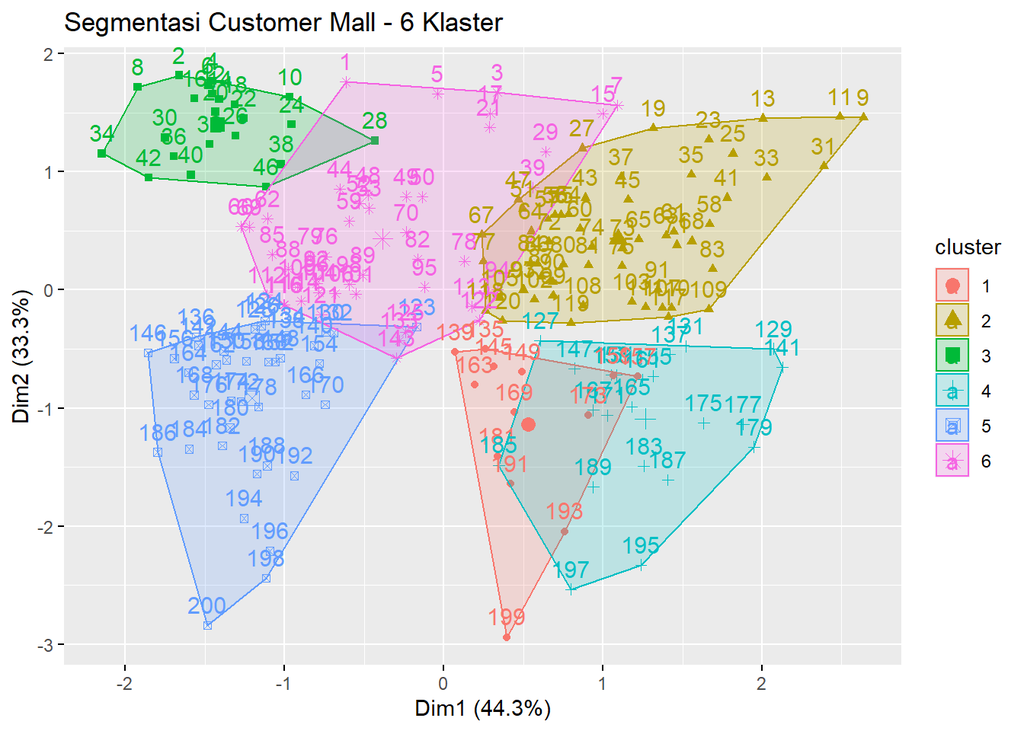

## Centroid klaster

Untuk merepresentasikan karakteristik tiap klaster kita dapat menggunakan acuan nilai means masing-masing variabel pada tiap kelompok yang terbentuk.

```r
aggregate(data_num, by=list(clus_cust$cluster),FUN=mean)
```

```
##   Group.1      Age Annual.Income..k.. Spending.Score..1.100.
## 1       1 30.46154           89.46154               13.38462
## 2       2 55.54386           47.94737               41.89474
## 3       3 25.27273           25.72727               79.36364
## 4       4 48.31818           87.50000               19.59091
## 5       5 32.87500           86.10000               81.52500
## 6       6 27.69565           49.58696               44.34783
```

Kategori 1 memiliki karakteristik penghasilan yang besar namun dengan pengeluaran yang sangat kecil.

Kategori 2 merupakan kumpulan customer yang sudah berumur dengan penghasilan dan pengeluaran yang standar.

Kategori 3 merupakan customer dengan kelompok umur muda yang memiliki penghsilan rendah namun pengeluaran yang cukup tinggi.

Kategori 4 memiliki karakteristik yang cukup mirip seperti kategori 1 dalam hal penghasilan dan pengeluaran, hanya saja dalam kelompok umur yang lebih tua.

Kategori 5 merupakan kelompok customer yang memiliki penghasilan tinggi dan diimbangi dengan pengeluaran yang tinggi pula.

Kategori 6 memiliki karakteristik yang cukup mirip seperti kategori 2 dalam hal penghasilan dan pengeluaran, namun dalam kelompok umur yang lebih muda.

```r
library(MVN)
```

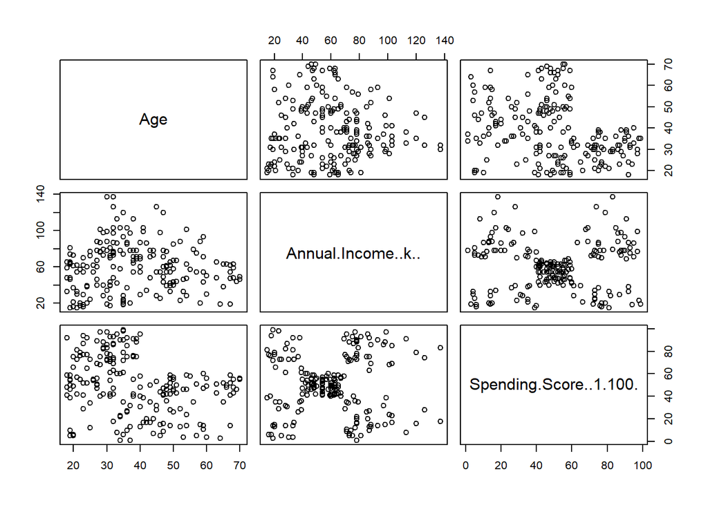

```r
plot(data_num, which = "map")
```